# R For Data Science Final Project

Bella Gagliardi, Caroline Kauh, Aditya Menon, Maya Williams

2024-07-29

```r
# loading all necessary packages
library(tidyverse)
library(gapminder)
library(countrycode)

# importing raw data for use in questions
athlete_events <- read_csv(
   file = 'athlete_events.csv',
   col_types = cols(ID = 'i', Age = 'i', Height = 'i', Year = 'i')
)

noc_regions <- read_csv(
  file = 'noc_regions.csv',
  col_types = cols(NOC = col_character(), region = col_character()
  ))

host_cities <- read_csv('host_cities.csv')
```

## Question 1:

```r
nearest_year <- function(olympic_year, gapminder_years) {
  gapminder_years[which.min(abs(gapminder_years - olympic_year))]
}
```

The above code was created in order to create a surrogate key in order to use GDP data that was closest to olympic years. This made it so that the data did not have any blanks even if there were GDP years reported data that did not match the years exactly. The program has been written to do the best it can with the data that it has.

```r
# Merging the Olympics data with region data using preloaded data packages
NOC_athEvents <- athlete_events %>%
  left_join(noc_regions, by = "NOC") %>%
  mutate(country = countrycode(NOC, "ioc", "country.name"))
# Using gapminder to align data based on country codes
gapminder_data <- gapminder %>%
  mutate(country = countrycode(country, "country.name", "country.name"))

# Splitting up data by which olympics it is from Summer or Winter
summer_athlete_events <- NOC_athEvents %>%
  filter(Season == "Summer")

winter_athlete_events <- NOC_athEvents %>%
  filter(Season == "Winter")

# Combining Olympics data with GDP data from gapminder using nearest year
combined_summer <- summer_athlete_events %>%
  mutate(nearest_year = sapply(Year, nearest_year, unique(gapminder_data$year))) %>%
  left_join(gapminder_data, by = c("country" = "country", "nearest_year" = "year"))

combined_winter <- winter_athlete_events %>%
  mutate(nearest_year = sapply(Year, nearest_year, unique(gapminder_data$year))) %>%
  left_join(gapminder_data, by = c("country" = "country", "nearest_year" = "year"))
```

To achieve the goal of creating graphs that compares number of athletes and medals to gdp for both summer and winter Olympics involved summarizing the results from the data sets. This involved grouping data together, filtering out unnecessary information, filtering out data depending on what olympics it related too and mutating data. The program was made to combine known data and create them in a way that would show a proper depcition of the data set wether that is in summary graph or summary format.

```r
# Summarizing the number of athletes and medals from each country per year for just the Summer Olympics data
summer_olympic_sum <- combined_summer %>%
  group_by(country, Year) %>%
  summarise(
    num_athletes = n(),num_medals = sum(!is.na(Medal)),gdpPercap = first(gdpPercap),
    .groups = 'drop'
  ) %>%


  mutate(country = countrycode(country, origin = "country.name", destination = "iso3c")) %>%
  filter(!is.na(gdpPercap))
winter_olympic_sum <- combined_winter %>%
  group_by(country, Year) %>%

  summarise(
    num_athletes = n(),num_medals = sum(!is.na(Medal)),gdpPercap = first(gdpPercap),
    .groups = 'drop'
  ) %>%

  mutate(country = countrycode(country, origin = "country.name", destination = "iso3c")) %>%
  filter(!is.na(gdpPercap))
```

```r
# Print the combined data for both Summer Olympics, gives general stats values for each dataset
print(summer_olympic_sum)
```

```
## # A tibble: 2,117 × 5
##    country  Year num_athletes num_medals gdpPercap
##    <chr>   <int>        <int>      <int>     <dbl>
##  1 AFG      1936           16          0      779.
##  2 AFG      1948           25          0      779.
##  3 AFG      1956           12          0      821.
##  4 AFG      1960           16          0      853.
##  5 AFG      1964            8          0      853.
##  6 AFG      1968            5          0      836.
##  7 AFG      1972            8          0      740.
##  8 AFG      1980           11          0      978.
##  9 AFG      1988            5          0      852.
## 10 AFG      1996            2          0      635.
## # ℹ 2,107 more rows
```

```r
# Print previously calculated correlation values for Winter Olympics
print(winter_olympic_sum)
```

```
## # A tibble: 767 × 5
##    country  Year num_athletes num_medals gdpPercap
##    <chr>   <int>        <int>      <int>     <dbl>
##  1 ALB      2006            3          0     5937.
##  2 ALB      2010            2          0     5937.
##  3 ALB      2014            2          0     5937.
##  4 DZA      1992            8          0     5023.
##  5 DZA      2006            3          0     6223.
##  6 DZA      2010            1          0     6223.
##  7 ARG      1928           10          0     5911.
##  8 ARG      1948           20          0     5911.
##  9 ARG      1952           21          0     5911.
## 10 ARG      1960           14          0     7133.
## # ℹ 757 more rows
```

In order to observe the trends between the number of medals won and number of athletes participating and how it correlates to a country’s GDP per capita, two separate dot plots were created - one plotting GDP per capita against number of athletes and the other that compared with GDP vs. number of medals won. The na.rm argument was used in the code for both plots as a way to remove Games data (NA) which was not needed since it did not have a GDP per capita recorded in the gapminder data set for that year so it could not be used. The result of all these changes and plotting it was that there appeared to be a slight positive trend in both number of participating athletes and number of medals won compared to a countries GDP per capita. Both plots also showed an increase in variability as GDP per capita increased.

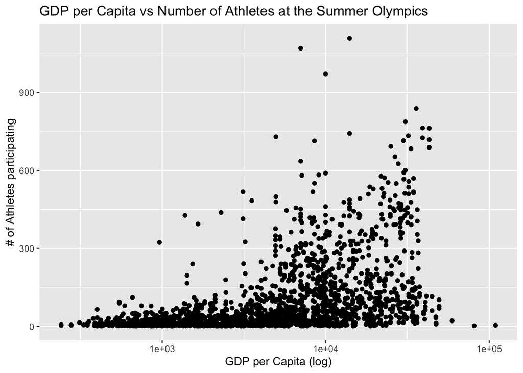

```r
# Creating graphs for Summer Olympics with log applied to the values so that they fit
ggplot(summer_olympic_sum, aes(x = gdpPercap, y = num_athletes)) +
  geom_point(na.rm = TRUE) +
  scale_x_log10() +
  labs(title = "GDP per Capita vs Number of Athletes at the Summer Olympics",
       x = "GDP per Capita (log)",
       y = "# of Athletes participating")
```

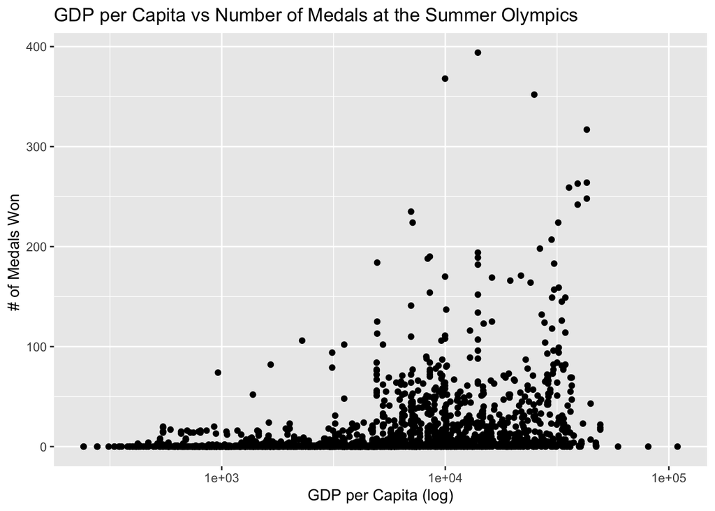

```r
ggplot(summer_olympic_sum, aes(x = gdpPercap, y = num_medals)) +
  geom_point(na.rm = TRUE) +
  scale_x_log10() +
  labs(title = "GDP per Capita vs Number of Medals at the Summer Olympics",
       x = "GDP per Capita (log)",
       y = "# of Medals Won ")
```

The most obvious outlier in the data set is in regard to number of athletes sent where the richest country for this value has a very low amount of athletes sent to the games. The results are not as strongly correlated compared to the winter games. Besides the richest country by that metric there are multiple countries that have large GDP per Capitas but low number of athletes sent and medals won.

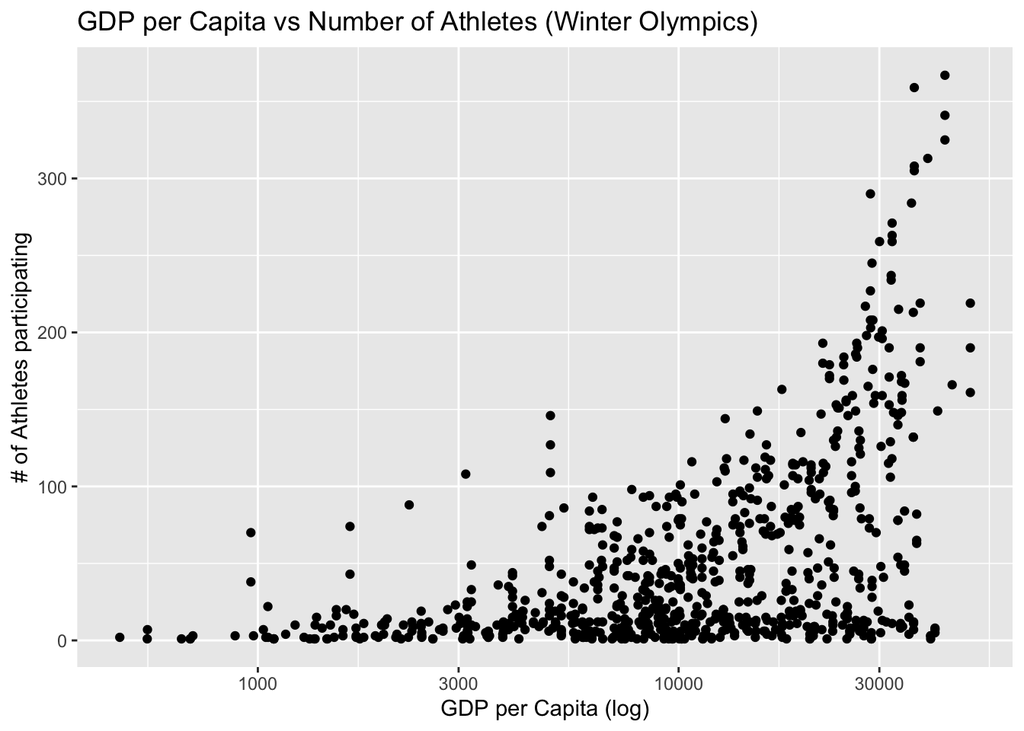

```r
# Creating graphs for Winter Olympics with log applied to the values so that they fit
ggplot(winter_olympic_sum, aes(x = gdpPercap, y = num_athletes)) +
  geom_point(na.rm = TRUE) +
  scale_x_log10() +
  labs(title = "GDP per Capita vs Number of Athletes (Winter Olympics)",
       x = "GDP per Capita (log)",
       y = "# of Athletes participating")
```

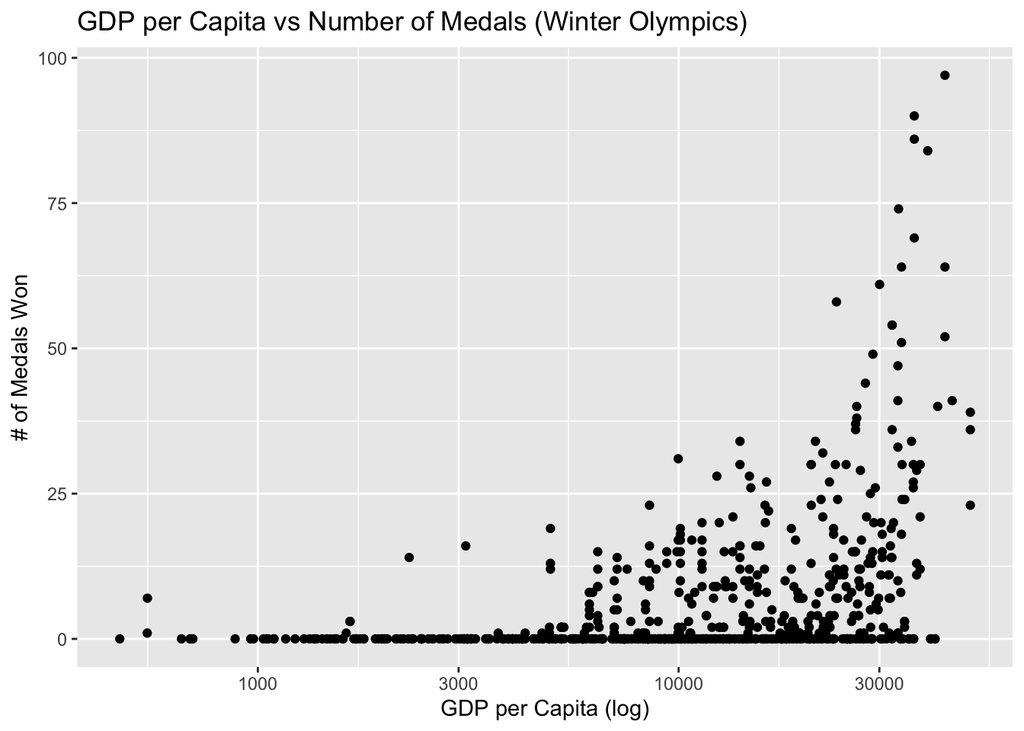

```r
ggplot(winter_olympic_sum, aes(x = gdpPercap, y = num_medals)) +
  geom_point(na.rm = TRUE) +
  scale_x_log10() +
  labs(title = "GDP per Capita vs Number of Medals (Winter Olympics)",
       x = "GDP per Capita (log)",
       y = "# of Medals Won")
```

In the data above the average data seems to be that richer countries have won more medals and send more athletes. The data does not seem to have many outliers (except for a few around the 1000 - 3500 mark where there are a few outliers and the 40000 gdp per capita some countries did not preform as well as they would be expected to). It should also be noted that the richest country by GDP per capita does not have the most medals won or atheltes sent. Tho in general as GDP per Capita increases so does number of athletes and number of medals won. Finally, correlation values were calculated for each of the above graphs, comparing both the correlation between GDP per capita and the number of athletes, this was done for both winter and summer olympics:

```r
# Calculating correlation values for Summer Olympics
cor_athletes_summer <- cor(summer_olympic_sum$gdpPercap, summer_olympic_sum$num_athletes, use = "complete.obs")
cor_medals_summer <- cor(summer_olympic_sum$gdpPercap, summer_olympic_sum$num_medals, use = "complete.obs")


# Print previously calculated correlation values for Summer Olympics

print(cor_athletes_summer)
```

```
## [1] 0.433593
```

```r
print(cor_medals_summer)
```

```
## [1] 0.3291061
```

Based on this data it seems that while there is a positive relationship between number of athletes/number of medals and the country they are from’s GDP per capita it is not very large especially when compared to the correlation values for the winter olympics. This indicates that there is a positive but not very strong connection between GDP per capita and athlete participating and medal amount won.

```r
# Calculating correlation values for Winter Olympics
cor_athletes_winter <- cor(winter_olympic_sum$gdpPercap, winter_olympic_sum$num_athletes, use = "complete.obs")
cor_medals_winter <- cor(winter_olympic_sum$gdpPercap, winter_olympic_sum$num_medals, use = "complete.obs")

# Print previously calculated correlation values for Winter Olympics
print(cor_athletes_winter)
```

```
## [1] 0.5879225
```

```r
print(cor_medals_winter)
```

```
## [1] 0.504975
```

Both of these values are positive and not extremely small, indicating there may be a significant correlation between both measured variables and GDP per capita. There seems to be much higher correlation in terms of athlete and medal production related to a country s GDP. This could be a multitude of reasons such as that generally winter sports are more expensive so more rich countries have the advantage in buying the best equipment possible.

## Question 2

The question to be investigated via the data displayed below is whether there is a correlation between what the host country is for each Summer Olympics and the number of medals that said country wins.

To examine this, we will create visual representations of the data comparing the amount of medals won by the host country in the year that they hosted the Olympics to the average amount of medals that the country wins. To begin, we transformed the athelete_events data, removing Winter games and joining it to the host_cities data. The data was then transformed to yield two important values - the mean number of medals won by each country per year, found by dividing the total number of metals won in a country’s Olympic history by the total number of Summer Olympic games in the dataset (stored as nSummerGames, 29 distinct values); and the number of metals won by each country in years that they hosted the Olympics. This two distinct datasets were then joined together to form the results_df table shown below, where average data is visible alongside the medal count for each host country. Already, a trend is visible - there are only three rows of the table in which the host country won fewer medals than its average.

```
## # A tibble: 23 × 4
## # Groups:   country.winner, Year [23]
##    country.winner  Year medalsWon avgMedals
##    <chr>          <int>     <int>     <dbl>
##  1 AUS             1956        67      45.0
##  2 AUS             2000       183      45.0
##  3 BEL             1920       188      15.7
##  4 BRA             2016        50      16.4
##  5 CAN             1976        23      25.6
##  6 CHN             2008       184      31.3
##  7 ESP             1992        69      16.8
##  8 FIN             1952        40      16.3
##  9 FRA             1900       235      56.1
## 10 FRA             1924       110      56.1
## # ℹ 13 more rows
```

The dotplot below better displays this contrast - triangular points represent actual number of medals won, with each color representing a host country; the blue dots represent the average number of medals for whichever country hosted that year. Even a cursory glance at the graph shows that most of the medal counts are far above, many more than double, the average medals won each year.

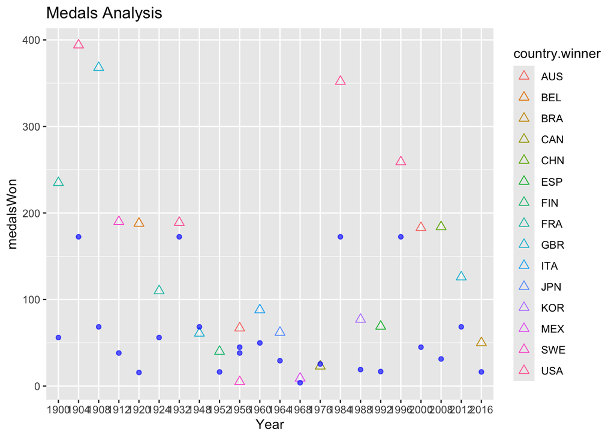

Finally, to drive home these results, this data is also collected into a bar chart, arranged by country, with a count of average medals won in blue beneath the number of medals won while hosting. Once again, almost all countries have a red bar visible above the blue, meaning that a majority of host countries won more medals than the average during their Summer Games.

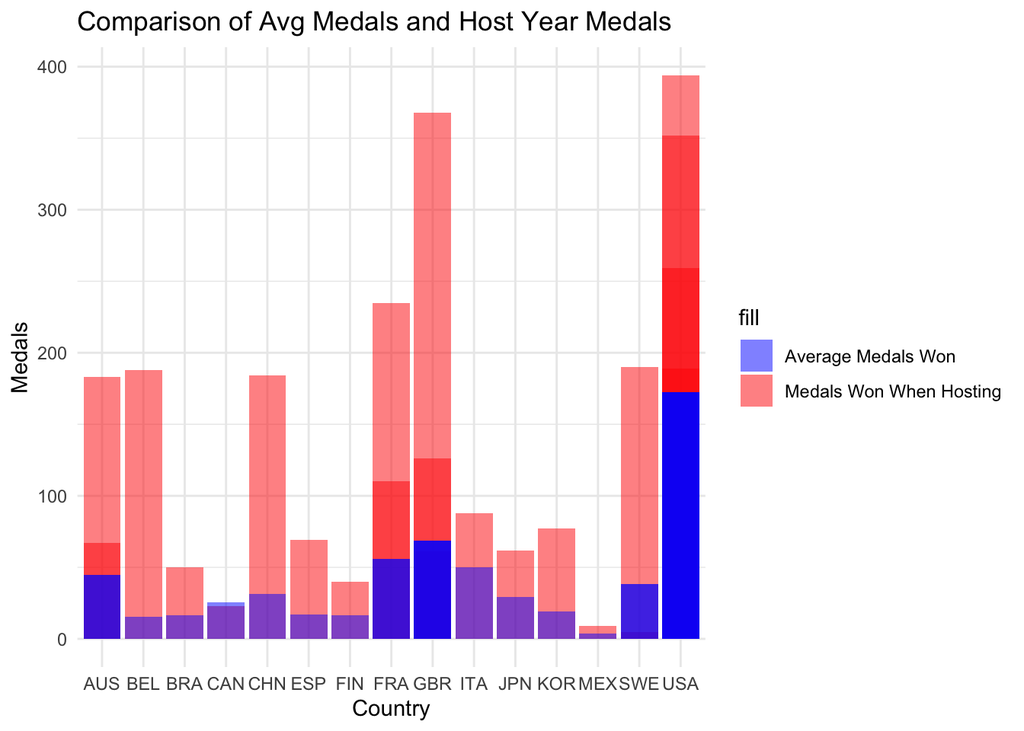

Based on this data, it is clear that there is a common trend where host countries, with only a few exceptions, tend to win more medals in the years they host than the average value across Summer Olympics past. While the data does not tell us a particular reason behind this, home-field advantage appears to be an Olympic phenomenon that may deserve further study.

# Question 3: Is there a link between the life expectancy of a country and the amount of Olympic medals that it wins?

When answering this question, the years with which there was life expectancy information and there were an Olympic Games were the years that were examined for any correlation. These years are 1952, 2002, 1992, and 1972.

Years that had no life expectancy data weren’t used. Additionally, years with life expectancy data but without an Olympic Games the year the data was collected weren’t used at all because life expectancy stats already are not guaranteed to be the same from year to year and there can be drastic events or developments in a country that can lead to the drastic increase or decrease in a country’s life expectancy (i.e. the Cambodian genocide carried out by the Khmer Rouge).

This table, a result of joining the gapminder data with the athlete_events data, selecting certain columns, and mutating both data frames to examine more metrics, shows the proportion of medals won by each country that had life expectancy data available for each year’s Olympic games along with where its life expectancy is ranked compared to other countries with that data available that year.

```
## # A tibble: 113 × 6
## # Groups:   year [4]
##    country lifeExp  year medals_won prop_medals lifeExp_rank
##    <chr>     <dbl> <int>      <int>       <dbl>        <dbl>
##  1 NOR        72.7  1952         32     0.0310             1
##  2 SWE        74.7  1972         26     0.0184             1
##  3 JPN        79.4  1992         59     0.0291             1
##  4 JPN        82    2002          2     0.00418            1
##  5 SWE        71.9  1952         93     0.0900             2
##  6 NOR        74.3  1972         25     0.0177             2
##  7 SWE        78.2  1992         42     0.0207             2
##  8 AUS        80.4  2002          2     0.00418            2
##  9 NZL        69.4  1952          3     0.00290            3
## 10 JPN        73.4  1972         59     0.0417             3
## # ℹ 103 more rows
```

Overall, based upon the following graphs, there is some evidence of a weak positive correlation between the life expectancy of a country and the amount of medals that it wins in the Olympics although the trend isn’t a perfectly linear one or a particularly strong one. In general, if a country has a higher proportion of medals won, it tends to have a higher life expectancy, but having a high life expectancy doesn’t seem to equate to having a higher proportion of medals won; this is especially evident in the year 2002, where the country with the highest life expectancy nearly has the lowest proportion of medals won. Additionally, having an extremely low life expectancy doesn’t seem to condemn a country to a low proportion of medals won as shown by year 1952 and year 2002.

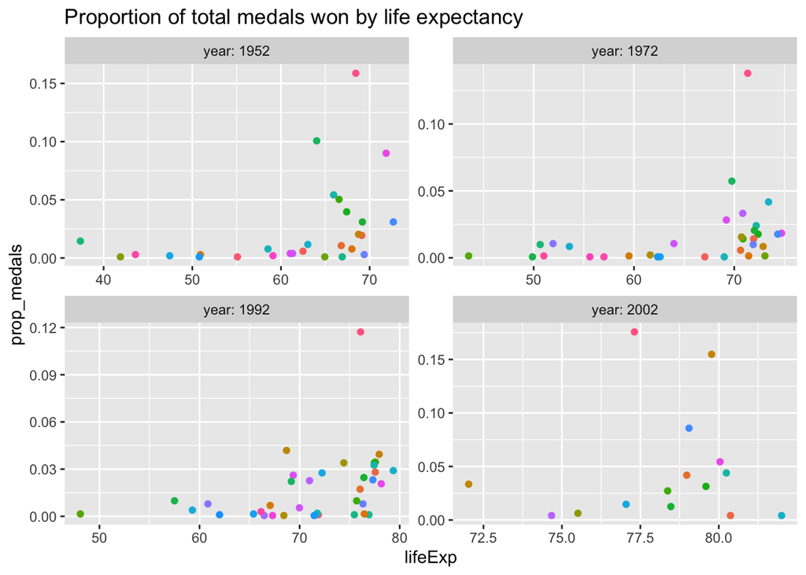

While there appears to be some evidence of an overall weak positive correlation between life expectancy and the proportion of medals won, having a better life expectancy rank than countries with a more comparable life expectancy rank doesn’t seem to be enough to give a nation an edge over another nation. In the case of top 10 life expectancy nations, none of the number one life expectancy countries managed to bring home the highest proportion of medals in any of the four years. Moreover, in at least 2 out of the 4 years, the 10th rank country, which is the lowest rank within this subset of life expectancy rankings, still manages to not bring home the lowest proportion of medals.

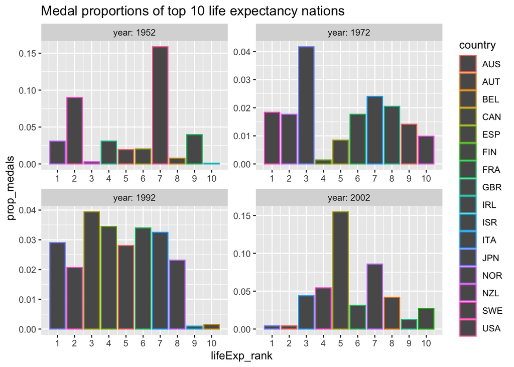

This is also true for the top 10 worst life expectancy nations (the worst country being the one with the highest ranking). In each of the four years, there appears to be no consistent trend in terms of which country brings home the highest or lowest proportion of medals. In fact, in 1952, the country with the worst life expectancy brought home more medals than the other 9 countries that outrank it.

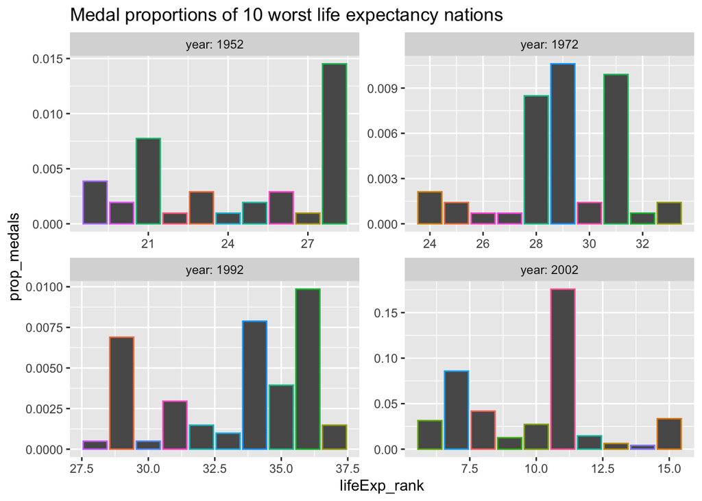